# **Exploratory Data Analysis**

#### **Table of Contents**:

1. Loading the libraries
2. Loading match data
   - 2.1. Cleaning, transformation, and missing values
   - 2.2. Creation of variables and measures
3. Exploratory Data Analysis
   - 3.1. Descriptive analysis
   - 3.2. Wins by year and player
   - 3.3. Number of *aces* or direct serve points by surface type
   - 3.4. Number of wins by year and country
   - 3.5. Number of wins by year, player, and tournament type
   - 3.6. Percentage of wins by year, player, and surface
   - 3.7. Effectiveness by year, player, and surface
   - 3.8. Distribution of the percentage of points won on first and second serves
4. Loading player data
   - 4.1. Best servers
   - 4.2. Best countries

## 1. **Loading the libraries**

The R libraries that we are going to use are imported below:

```r
library(ggplot2)
library(tidyverse)
library(tidyr)
library(dplyr)
library(writexl)
library(gridExtra)
library(grid)
library(knitr)
```

These libraries will help us perform data visualization tasks, manipulate, transform, and analyze the data.

## 2. **Loading match data**

We will start by loading the data from the file atp_matches_2000_2023.csv as part of our main dataset:

```r
datos = read.csv("../data/raw-data/atp_matches_2000_2023.csv")
```

The data file has 71830 rows and 49 columns. Therefore, from the year 2000 to 2023, we have data for 71830 matches, since each row represents a match with information about the winner and the loser. The meaning of each variable and its type is described in the attached file **Appendix Variables - Final Dataset.pdf**. The structure of the dataset is as follows:

```
## 'data.frame':    71830 obs. of  49 variables:
##  $ tourney_id        : chr  "2000-301" "2000-301" "2000-301" "2000-301" ...
##  $ tourney_name      : chr  "Auckland" "Auckland" "Auckland" "Auckland" ...
##  $ surface           : chr  "Hard" "Hard" "Hard" "Hard" ...
##  $ draw_size         : int  32 32 32 32 32 32 32 32 32 32 ...
##  $ tourney_level     : chr  "A" "A" "A" "A" ...
##  $ tourney_date      : int  20000110 20000110 20000110 20000110 20000110 20000110 20000110 20000110 20000110 20000110 ...
##  $ match_num         : int  1 2 3 4 5 6 7 8 9 10 ...
##  $ winner_id         : int  103163 102607 103252 103507 102103 102021 101320 102563 102854 102494 ...
##  $ winner_seed       : int  1 NA NA 7 NA NA NA 5 6 NA ...
##  $ winner_entry      : chr  "" "Q" "" "" ...
##  $ winner_name       : chr  "Tommy Haas" "Juan Balcells" "Alberto Martin" "Juan Carlos Ferrero" ...
##  $ winner_hand       : chr  "R" "R" "R" "R" ...
##  $ winner_ht         : int  188 190 175 183 180 175 185 180 193 193 ...
##  $ winner_ioc        : chr  "GER" "ESP" "ESP" "ESP" ...
```

[output cut: 36 more lines]

#### 2.1. **Cleaning, transformation, and missing values**

As mentioned, each row represents a match and contains data about both the loser and the winner. However, to make the analysis easier, we will transform the dataset so that each match is represented by two rows. In the first row we will include the match data and the winner’s data, and in the second row the match data and the loser’s data. We will start by defining two variables: one that contains the variables related to the winning player, and another that contains the variables related to the losing player:

```r
variables_ganador = c("tourney_id", "tourney_name", "surface", "draw_size",
                      "tourney_level", "tourney_date", "match_num","score", "best_of",
                      "round", "minutes", "winner_id", "winner_seed", "winner_entry", "winner_name", "winner_hand",
                      "winner_ht", "winner_ioc", "winner_age",  "w_ace", "w_df", "w_svpt", "w_1stIn",
                      "w_1stWon", "w_2ndWon", "w_SvGms", "w_bpSaved", "w_bpFaced",
                      "winner_rank", "winner_rank_points")

variables_perdedor = c("tourney_id", "tourney_name", "surface", "draw_size",
                       "tourney_level", "tourney_date", "match_num","score", "best_of",
                       "round", "minutes", "loser_id", "loser_seed", "loser_entry", "loser_name", "loser_hand",
                       "loser_ht", "loser_ioc", "loser_age",  "l_ace", "l_df", "l_svpt", "l_1stIn",
                       "l_1stWon", "l_2ndWon", "l_SvGms", "l_bpSaved", "l_bpFaced",
                       "loser_rank", "loser_rank_points")
```

Next, with the following code, we will create two variables (`datos_ganador`, `datos_perdedor`) that will select the columns found in the vectors of the two previously defined variables for winner and loser, and we will rename the columns that begin with the corresponding prefixes (“winner_”, “w_”, “loser_”, “l_”) by removing those prefixes. Afterwards, we add a new column called **“player_type”**, which will indicate whether the player was the **winner** or the **loser** of the match. This will be stored in two different *data frames*.

```r
datos_ganador = datos %>% select(all_of(variables_ganador)) %>%
  rename_with(~str_replace(., "^(winner_|w_)", ""), starts_with(c("winner_", "w_"))) %>%
  mutate(player_type = "winner")

datos_perdedor = datos %>% select(all_of(variables_perdedor)) %>%
  rename_with(~str_replace(., "^(loser_|l_)", ""), starts_with(c("loser_", "l_"))) %>%
  mutate(player_type = "loser")
```

Finally, we combine the two previous *data frames* (`datos_ganador`, `datos_perdedor`) into a single one. This *data frame*, called **datos_final**, will contain the separated data of the winner and the loser of each match. In addition, we sort it by the tournament identifier **“tourney_id”** and by the match number **“match_num”**. On the other hand, we will remove the column or variable **“entry”**, which represents the player’s mode of entry into the tournament. Since we do not consider it important, we will drop it from the dataset:

```r
datos_final = bind_rows(datos_ganador, datos_perdedor)
datos_final = datos_final %>% arrange(tourney_id, match_num)
datos_final = subset(datos_final, select = -entry)
```

Next, from the variable **“tourney_date”**, we will create two columns that indicate the year and the month of the match:

```r
datos_final$tourney_date = as.character(datos_final$tourney_date)
datos_final$Year = as.numeric(as.character(substr(datos_final$tourney_date, 1, 4)))
datos_final$Month = as.numeric(as.character(substr(datos_final$tourney_date, 6, 6)))
```

The structure of the final dataset is as follows:

```
## 'data.frame':    143660 obs. of  32 variables:
##  $ tourney_id   : chr  "2000-301" "2000-301" "2000-301" "2000-301" ...
##  $ tourney_name : chr  "Auckland" "Auckland" "Auckland" "Auckland" ...
##  $ surface      : chr  "Hard" "Hard" "Hard" "Hard" ...
##  $ draw_size    : int  32 32 32 32 32 32 32 32 32 32 ...
##  $ tourney_level: chr  "A" "A" "A" "A" ...
##  $ tourney_date : chr  "20000110" "20000110" "20000110" "20000110" ...
##  $ match_num    : int  1 1 2 2 3 3 4 4 5 5 ...
##  $ score        : chr  "7-5 4-6 7-5" "7-5 4-6 7-5" "7-5 7-5" "7-5 7-5" ...
##  $ best_of      : int  3 3 3 3 3 3 3 3 3 3 ...
##  $ round        : chr  "R32" "R32" "R32" "R32" ...
##  $ minutes      : int  108 108 85 85 56 56 68 68 115 115 ...
##  $ id           : int  103163 101543 102607 102644 103252 102238 103507 103819 102103 102765 ...
##  $ seed         : int  1 NA NA NA NA NA 7 NA NA 4 ...
##  $ name         : chr  "Tommy Haas" "Jeff Tarango" "Juan Balcells" "Franco Squillari" ...
```

[output cut: 19 more lines]

Our final dataset has 143660 rows and 32 columns. This makes sense because it is double the number of rows we had before, as each match is now represented by two rows instead of one. On the other hand, we have reduced the number of variables from 49 to 32, although the information has been preserved through the transformation.

Now, let’s check how many missing values there are in our data by variable. We will create a new *data frame* that contains the number of null values per variable in the dataset:

```r
valores_faltantes = data.frame(Variable = names(datos_final), Missing_Values = sapply(datos_final, function(x) sum(is.na(x))), row.names = c(1:32))
valores_faltantes_con_nulos = valores_faltantes[valores_faltantes$Missing_Values > 0, ]
print(knitr::kable(valores_faltantes_con_nulos[order(valores_faltantes_con_nulos$Missing_Values, decreasing = TRUE),]))
```

```
##
##
## |   |Variable    | Missing_Values|
## |:--|:-----------|--------------:|
## |13 |seed        |          97353|
## |11 |minutes     |          15872|
## |19 |ace         |          12920|
## |20 |df          |          12920|
## |21 |svpt        |          12920|
## |22 |1stIn       |          12920|
## |23 |1stWon      |          12920|
## |24 |2ndWon      |          12920|
## |26 |bpSaved     |          12920|
## |27 |bpFaced     |          12920|
## |25 |SvGms       |          12918|
## |16 |ht          |           5081|
## |28 |rank        |           1989|
## |29 |rank_points |           1989|
## |18 |age         |             19|
```

As we can observe, the variable **“seed”** has 97,353 missing or null values. Since this variable contains the pre-assigned position in the competition draw for the player, we do not consider it an interesting or relevant variable for the analysis. Therefore, we will remove this column from the dataset:

```r
datos_final = subset(datos_final, select = -seed)
```

Now let’s check if we can detect for which tournaments these missing values occur. We will test with the null values:

```r
datos_con_nulos_minutos = subset(datos_final, is.na(minutes))
nulos_por_torneo_minutos = table(datos_con_nulos_minutos$tourney_level)
```

```
##
##     A     D     F     G     M
##  2854 11370    70   812   766
```

```r
datos_con_nulos_aces = subset(datos_final, is.na(ace))
nulos_por_torneo_aces = table(datos_con_nulos_aces$tourney_level)
```

```
##
##     A     D     F     G     M
##  1300 11206    24    82   308
```

At first glance, we can see that tournaments with level **“D”**, that is, Davis Cup tournaments, are the ones with the most missing values in several columns. This type of tournament is not among the most important, so we are not concerned about having so many null values for it. However, we will remove the rows where the variable **“tourney_level”** has the value **“D”**:

```r
datos_final = datos_final[datos_final$tourney_level != "D",]
```

```r
datos_final = datos_final[!is.na(datos_final$ace), ]
```

Now let’s look at the observations we have for each type of surface:

```r
count_por_superficie = datos_final %>% group_by(surface) %>% summarise(valores = n())
```

```
## # A tibble: 4 × 2
##   surface valores
##   <chr>     <int>
## 1 Carpet     2842
## 2 Clay      41234
## 3 Grass     14246
## 4 Hard      70170
```

As we can see, there are 2842 values for the “Carpet” surface. Since there are few observations of this type of surface and its use ended in 2009, it is not very relevant for this analysis. Therefore, we will remove it from the dataset.

```r
datos_final = datos_final[datos_final$surface != "Carpet",]
```

Let’s check the null values in our final dataset:

```r
valores_faltantes = data.frame(Variable = names(datos_final), Missing_Values = sapply(datos_final, function(x) sum(is.na(x))), row.names = c(1:31))
valores_faltantes_con_nulos = valores_faltantes[valores_faltantes$Missing_Values > 0, ]
valores_faltantes_con_nulos = valores_faltantes_con_nulos[order(valores_faltantes_con_nulos$Missing_Values, decreasing = TRUE), ]
```

|  | Variable | Missing_Values |
| --- | --- | --- |
| 11 | minutes | 2908 |
| 15 | ht | 965 |
| 27 | rank | 225 |
| 28 | rank_points | 225 |
| 17 | age | 4 |

As we can see, we will only have null values in the variables **minutes**, **ht**, **age**, **rank**, and **rank_points**.

#### 2.3. **Creation of variables and measures**

In addition to creating the variables player_type, Year, Month, we will create new variables that we will later use in the exploratory analysis. We will start by creating three variables that will contain, for each match and player, the percentage of points won on the first serve, the percentage of points won on the second serve, and the percentage of first serves made:

```r
datos_final = datos_final %>% mutate(`%_pw_1st_serve` = ifelse(`1stIn` > 0, `1stWon` / `1stIn` * 100, 0))
datos_final = datos_final %>% mutate(`%_pw_2nd_serve` = ifelse((svpt - `1stIn` - df) > 0, (`2ndWon` / (svpt - `1stIn` - df)) * 100, 0))
datos_final = datos_final %>% mutate(`%1stIn` = ifelse(`1stIn` > 0, (`1stIn` / svpt ) * 100,0))
```

## 3. **Exploratory Data Analysis**

#### 3.1. **Descriptive analysis**

We will begin with a brief descriptive analysis of some of our variables:

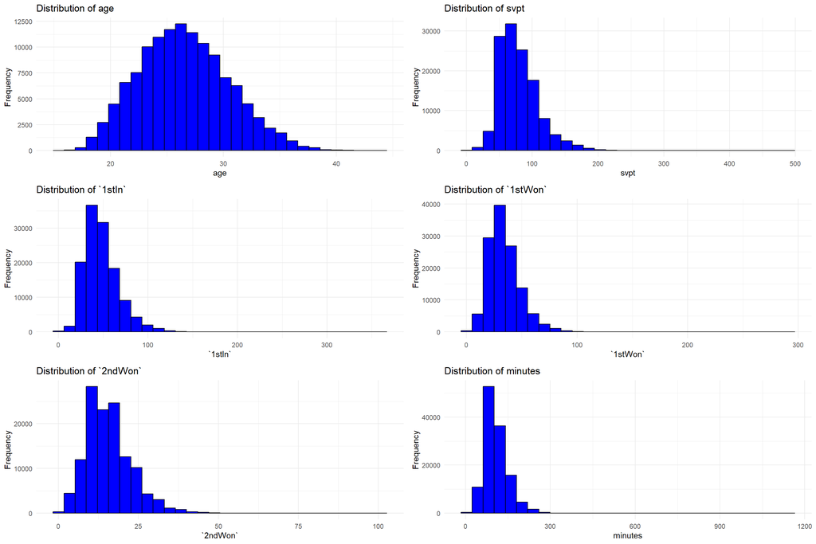

```r
variables_eda1 = c("age", "svpt", "`1stIn`", "`1stWon`", "`2ndWon`", "minutes")

plot_histogram = function(var) {
  ggplot(datos_final, aes_string(x = var)) +
    geom_histogram(bins = 30, fill = "blue", color = "black") +
    labs(title = paste("Distribution of", var),
         x = var,
         y = "Frequency") +
    theme_minimal()
}
histograms = lapply(variables_eda1, plot_histogram)
gridExtra::grid.arrange(grobs = histograms, ncol = 2)
```

Explanations:

- Distribution of **“age”**: The distribution appears approximately normal and centered around 27 years old, suggesting that most tennis players are around that age.
- Distribution of **“svpt”** (number of serve points): Most players seem to have a number of serve points ranging between 50 and 150.
- Distribution of **“1stIn”** (number of valid first serves): The distribution is right-skewed, with most players having between 0 and 100 valid first serves. The distribution is similar to **“1stWon”** (number of first serves won).
- Distribution of **“2ndWon”** (number of points won on the second serve): Most players win between 0 and 25 points with their second serve.
- Distribution of **“minutes”** (match duration in minutes): Most matches last around 2 hours.

#### 3.2. **Number of wins per year and player**

Now we will create a plot that shows the number of wins per year achieved by the 10 players with the most wins in our dataset:

```r
victorias_tenistas = datos_final %>% filter(player_type == "winner") %>% group_by(Year, name) %>% summarise(victorias = n(), .groups = 'drop')
top_tenistas = victorias_tenistas %>% group_by(name) %>% summarise(total_victorias = sum(victorias), .groups = 'drop') %>% top_n(10, total_victorias)
victorias_top_tenistas = victorias_tenistas %>% filter(name %in% top_tenistas$name)
```

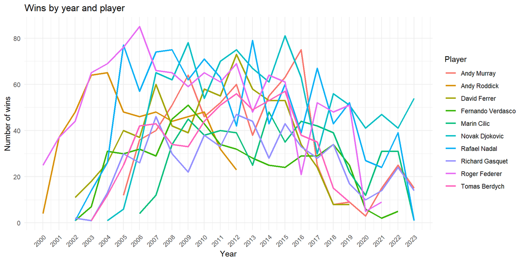

```r
ggplot(victorias_top_tenistas, aes(x = Year, y = victorias, color = name)) + geom_line() + labs(title = "Wins by year and player",
                                                                                      x = "Year",
                                                                                      y = "Number of wins",
                                                                                      color = "Player") +
  theme_minimal() + theme(axis.text.x = element_text(angle = 45, hjust = 1)) +
  scale_x_continuous(breaks = seq(min(victorias_top_tenistas$Year), max(victorias_top_tenistas$Year), by = 1)) + geom_line(size = 1)
```

We can clearly see how most players experience fluctuations in the number of wins over the years, which is normal in a sports career due to factors such as physical condition, injuries, or streaks. Some players show performance peaks in certain years, which could correspond to their best seasons. For example, we can observe that players like Novak Djokovic, Rafael Nadal, and Roger Federer have multiple years with a high number of wins, which is indicative of their success and consistency in this sport. Players whose lines start later in the chart, such as Marin Cilic, probably began their professional careers after the year 2000, while those whose lines end before 2023 may have retired or reduced their participation in tournaments, such as Roger Federer.

#### 3.3. **Number of *aces* or direct serve points by surface type**

We will now create a plot or visualization that shows the distribution of the number of “aces” by surface type:

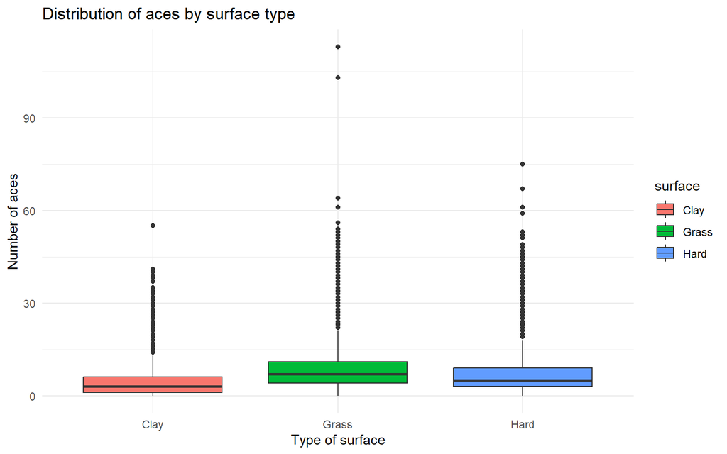

```r
ggplot(datos_final, aes(x = surface, y = ace, fill = surface)) + geom_boxplot() + labs(title = "Distribution of aces by surface type",
                                                                                       x = "Type of surface",
                                                                                       y = "Number of aces") + theme_minimal()
```

It can be observed that the average number of direct serve points (aces) is lower and shows less variability on clay compared to grass and hard courts, indicating that aces are less common on clay. Grass courts present a wider distribution, suggesting greater variability in the number of aces on this surface, probably due to the higher speed and lower friction that favor powerful serves. Hard courts show moderate dispersion and an average higher than clay but lower than grass, reflecting a balance in the frequency of aces among the three surfaces.

#### 3.4. **Number of wins per year and country**

We will now create a plot that shows the total number of wins distributed by players’ countries and by year, selecting the 10 countries with the most wins:

```r
victorias = datos_final %>% filter(player_type == "winner") %>% group_by(Year, ioc) %>% summarise(victories = n(), .groups = 'drop')
top_paises = victorias %>% group_by(ioc) %>% summarise(total_victories = sum(victories), .groups = 'drop') %>% top_n(10, total_victories)
victorias_top = victorias %>% filter(ioc %in% top_paises$ioc)
```

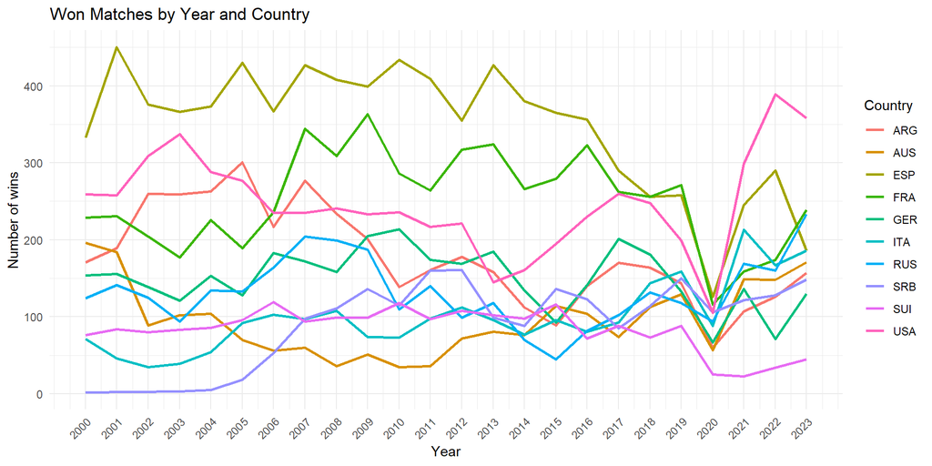

```r
ggplot(victorias_top, aes(x = Year, y = victories, color = ioc)) + geom_line() + labs(title = "Won Matches by Year and Country",
                                                                                      x = "Year",
                                                                                      y = "Number of wins",
                                                                                      color = "Country") +
  theme_minimal() + theme(axis.text.x = element_text(angle = 45, hjust = 1)) +
  scale_x_continuous(breaks = seq(min(victorias_top$Year), max(victorias_top$Year), by = 1)) + geom_line(size = 1)
```

#### 3.5. **Number of wins per year, player, and tournament type**

Next, we build a function that creates a plot showing the number of wins of a player per year and by tournament type.

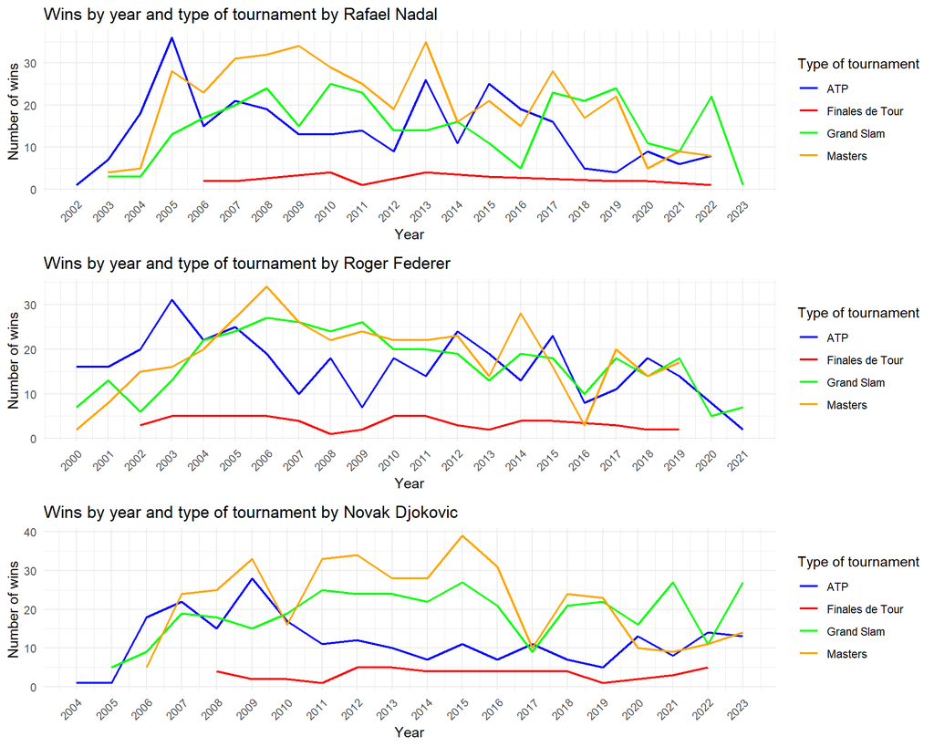

```r
plot_victorias_tenista_por_torneo = function (tenista, datos_final) {
    tenista_victorias = datos_final %>% filter(name == tenista & player_type == "winner") %>% group_by(Year, tourney_level) %>%
                         summarise(victorias = n(), .groups = 'drop')
    ggplot(tenista_victorias, aes(x = Year, y = victorias, color = tourney_level)) +
      geom_line(size = 0.8) +
      scale_x_continuous(breaks = seq(min(tenista_victorias$Year), max(tenista_victorias$Year), by = 1)) +
      scale_color_manual(values = c("A" = "blue", "F" = "red", "G" = "green", "M" = "orange"),
                         labels = c("ATP", "Finales de Tour", "Grand Slam", "Masters")) +
      labs(title = paste("Wins by year and type of tournament by", tenista),
           x = "Year",
           y = "Number of wins",
           color = "Type of tournament") +
      theme_minimal() + theme(axis.text.x = element_text(angle = 45, hjust = 1))
}
```

#### 3.6. **Win percentage per year, player, and surface**

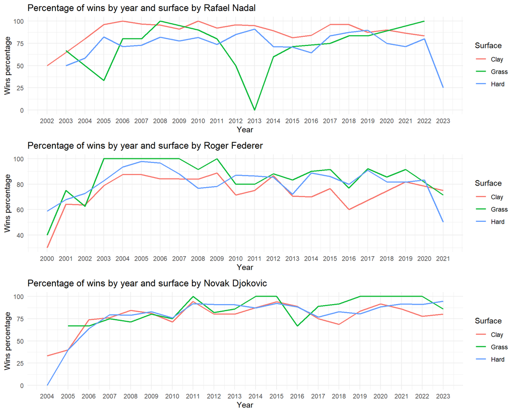

```r
plot_victorias_tenista_por_superficie = function (tenista, datos_final){
    tenista_victorias_superficie = datos_final %>%
      filter(name == tenista & player_type == "winner") %>%
      group_by(Year, surface) %>%
      summarise(victories = n(), .groups = 'drop')

    tenista_derrotas_superficie = datos_final %>%
      filter(name == tenista & player_type == "loser") %>%
      group_by(Year, surface) %>%
      summarise(derrotas = n(), .groups = 'drop')

    tenista_porcentaje_victorias_superficie = full_join(tenista_victorias_superficie, tenista_derrotas_superficie, by = c("Year", "surface")) %>%
      replace_na(list(victories = 0, derrotas = 0)) %>%
      mutate(total_partidos = victories + derrotas,
             porcentaje_victorias = ifelse(total_partidos > 0, (victories / total_partidos) * 100, 0))
    ggplot(tenista_porcentaje_victorias_superficie, aes(x = Year, y = porcentaje_victorias, color = surface)) +
    geom_line(size = 0.8) +
    scale_x_continuous(breaks = seq(min(tenista_porcentaje_victorias_superficie$Year), max(tenista_porcentaje_victorias_superficie$Year), by = 1)) +
    labs(title = paste("Percentage of wins by year and surface by", tenista),
       x = "Year",
       y = "Wins percentage",
       color = "Surface") +
    theme_minimal()
}
```

In this chart, Nadal stands out particularly on clay courts, showing a consistently high win percentage, which reflects his well-known dominance on this surface. Federer and Djokovic have a more balanced performance across surfaces, although Federer has a slight edge on grass, highlighting his skill on this fast surface. Djokovic, on the other hand, shows a remarkable ability to maintain a high win percentage on all surfaces, emphasizing his versatility as a player.

#### 3.7. **Effectiveness per year, player, and surface**

Next, we will create a function similar to the previous one, but instead of the number of wins, we will calculate the effectiveness in percentage for each player and surface type:

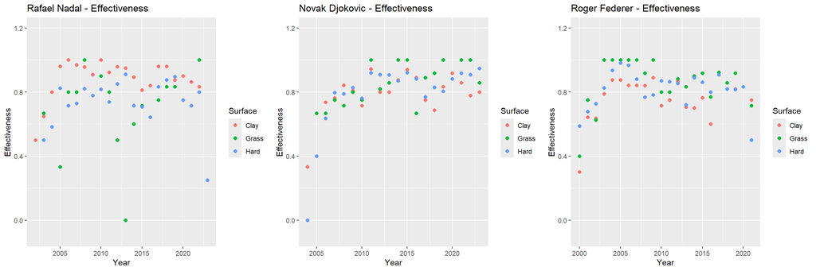

```r
plot_efectividad = function(jugador, datos_final) {
  victorias = datos_final %>% filter(name == jugador & player_type == "winner") %>% count(Year, surface, name = "victorias")
  derrotas = datos_final %>% filter(name == jugador & player_type == "loser") %>% count(Year, surface, name = "derrotas")

  efectividad = full_join(victorias, derrotas, by = c("Year", "surface")) %>%
    replace_na(list(victorias = 0, derrotas = 0)) %>%
    mutate(total_partidos = victorias + derrotas, ef = ifelse(total_partidos > 0, victorias / total_partidos, 1))

  ggplot(efectividad, aes(x = Year, y = ef, color = surface)) +
    geom_point(size = 2) + scale_y_continuous(limits = c(-0.1, 1.2)) +
    labs(
      title = paste(jugador, "- Effectiveness"),
      x = "Year",
      y = "Effectiveness",
      color = "Surface"
    )
}
```

We observe again the same pattern as in the previous chart. In the case of Rafa Nadal, there is a greater concentration of points on clay courts above 0.8, which indicates high effectiveness, consistent with his reputation as the “King of Clay.” Djokovic shows effectiveness more evenly distributed across all surfaces. For Federer, there is notable effectiveness on grass courts.

#### 3.8. **Distribution of the percentage of points won on first and second serves**

Next, we will create charts showing the distribution of points won on first and second serves, depending on whether the player is the winner or the loser:

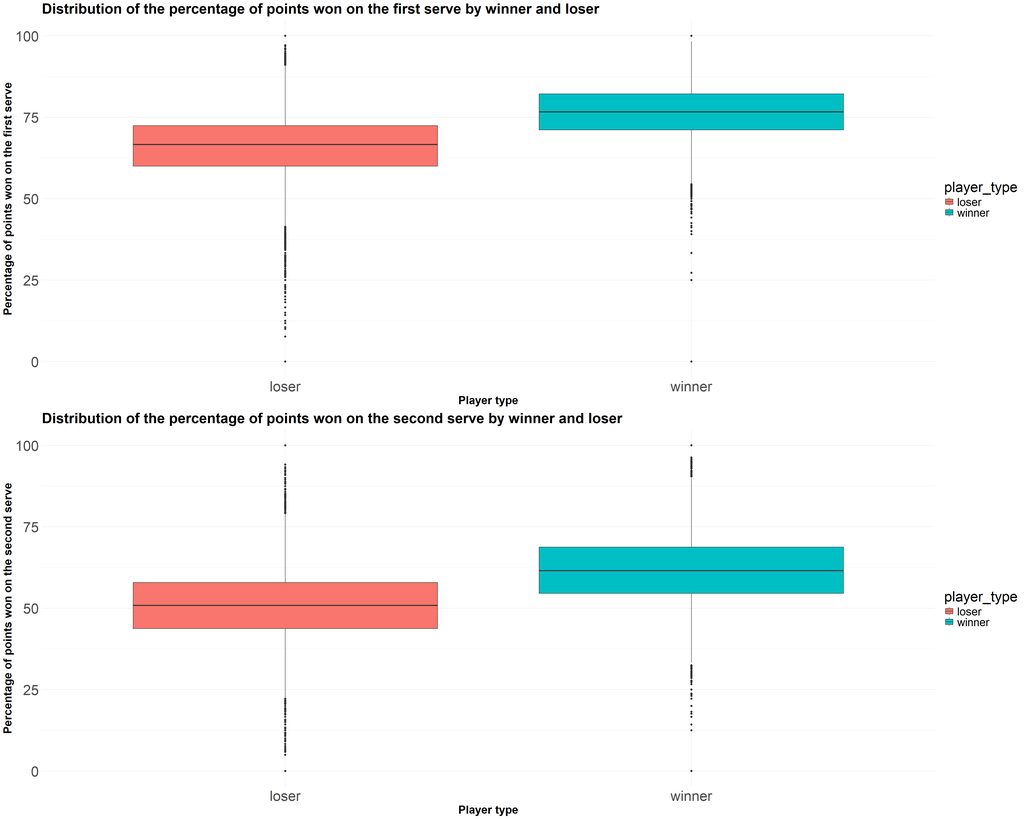

```r
p4 = ggplot(datos_final, aes(x = player_type, y = `%_pw_1st_serve`, fill = player_type)) +
  geom_boxplot() +
  labs(
    title = "Distribution of the percentage of points won on the first serve by winner and loser",
    x = "Player type",
    y = "Percentage of points won on the first serve"
  ) +
  theme_minimal() +
  theme(
    plot.title = element_text(size = 25, face = "bold"),
    axis.title.x = element_text(size = 20, face = "bold"),
    axis.title.y = element_text(size = 20, face = "bold"),
    axis.text.x = element_text(size = 25),
    axis.text.y = element_text(size = 25),
    legend.title = element_text(size = 25),
    legend.text = element_text(size = 20)
  )

p5 = ggplot(datos_final, aes(x = player_type, y = `%_pw_2nd_serve`, fill = player_type)) +
  geom_boxplot() +
  labs(
    title = "Distribution of the percentage of points won on the second serve by winner and loser",
    x = "Player type",
    y = "Percentage of points won on the second serve"
  ) +
  theme_minimal() +
  theme(
    plot.title = element_text(size = 25, face = "bold"),
    axis.title.x = element_text(size = 20, face = "bold"),
    axis.title.y = element_text(size = 20, face = "bold"),
    axis.text.x = element_text(size = 25),
    axis.text.y = element_text(size = 25),
    legend.title = element_text(size = 25),
    legend.text = element_text(size = 20)
  )

gridExtra::grid.arrange(p4, p5, nrow = 2)
```

The charts above show the distribution of the percentage of points won on the first and second serve by winners and losers. On the first serve, both winners and losers show a wide distribution of effectiveness, but winners generally win a higher percentage of points on their first serve than losers. This pattern is repeated on the second serve, although with a lower median for both, indicating that points won on the second serve are generally fewer than on the first serve.

## 4. **Loading player data**

```r
matches=datos_final
m = matches[!is.na(matches$ace), ]
numero_valores_faltantes = sum(is.na(m$df))
numero_valores_faltantes
```

```
## [1] 0
```

```r
players=read.csv("../data/raw-data/atp_players.csv")
players$appear = ifelse(!is.na(match(players$player_id, unique(m$id))), 1, 0)
players2=players[players$appear==1, ]
#Eliminamos la columna appear
players2=players2[, -c(8)]
#Eliminamos el ranking de dobles y su ID de Wikidata
players2=players2[, -c(8)]
```

```r
playersTotal=players2
frecuenciaTotal = table(m$id)
head(frecuenciaTotal, 5)
```

```
##
## 100644 101086 101150 101167 101185
##    544     26     71      1     10
```

```r
playersTotal$appearences = frecuenciaTotal[names(frecuenciaTotal)==playersTotal$player_id]
#Victorias
winsTotal = table(m$id[m$player_type=='winner'])
winning_players=names(winsTotal)
playersTotal$wins = 0
playersTotal$wins[playersTotal$player_id %in% winning_players] = winsTotal[winning_players]
#Derrotas
playersTotal$loses=playersTotal$appearences-playersTotal$wins
#% de
playersTotal$win_per=playersTotal$wins/playersTotal$appearences*100
playersTotal$win_per=round(playersTotal$win_per, 2)
library(dplyr)
#Aces
tabla_aces = aggregate(ace ~ id, matches, sum)
playersTotal$aces=tabla_aces$ace[playersTotal$player_id==tabla_aces$id]
#Dobles Faltas
tabla_df = aggregate(df ~ id, matches, sum)
playersTotal$df=tabla_df$df[playersTotal$player_id==tabla_df$id]
#Puntos de servicio
tabla_svpt = aggregate(svpt ~ id, matches, sum)
playersTotal$svpt=tabla_svpt$svpt[playersTotal$player_id==tabla_svpt$id]
#Cambiamos los nombres de las variables que empiezan con numero
colnames(matches)[colnames(matches) == "1stIn"] = "X1stIn"
colnames(matches)[colnames(matches) == "1stWon"] = "X1stWon"
colnames(matches)[colnames(matches) == "2ndWon"] = "X2ndWon"
#Primeros saques metidos
tabla_X1stIn = aggregate(X1stIn ~ id, matches, sum)
playersTotal$X1stIn=tabla_X1stIn$X1stIn[playersTotal$player_id==tabla_X1stIn$id]
#% de primeros saques metidos
playersTotal$`%1stIn`=round(playersTotal$X1stIn/playersTotal$svpt*100, 2)
#Primeros saques ganados
tabla_X1stWon = aggregate(X1stWon ~ id, matches, sum)
playersTotal$X1stWon=tabla_X1stWon$X1stWon[playersTotal$player_id==tabla_X1stWon$id]
#% de primeros saques ganados
playersTotal$`%1stWon`=round(playersTotal$X1stWon/playersTotal$X1stIn*100, 2)
#Segundos saques metidos
playersTotal$X2ndIn=playersTotal$svpt - playersTotal$X1stIn - playersTotal$df
#Segundos saques ganados
tabla_X2ndWon = aggregate(X2ndWon ~ id, matches, sum)
playersTotal$X2ndWon=tabla_X2ndWon$X2ndWon[playersTotal$player_id==tabla_X2ndWon$id]
#% de segundos saques ganados
playersTotal$`%2ndWon`=round(playersTotal$X2ndWon/playersTotal$X2ndIn*100,2)
#Juegos de servicios
tabla_SvGms = aggregate(SvGms ~ id, matches, sum)
playersTotal$SvGms=tabla_SvGms$SvGms[playersTotal$player_id==tabla_SvGms$id]
#Puntos de break salvados
tabla_bpSaved = aggregate(bpSaved ~ id, matches, sum)
playersTotal$bpSaved=tabla_bpSaved$bpSaved[playersTotal$player_id==tabla_bpSaved$id]
#Puntos de break
tabla_bpFaced = aggregate(bpFaced ~ id, matches, sum)
playersTotal$bpFaced=tabla_bpFaced$bpFaced[playersTotal$player_id==tabla_bpFaced$id]
#Puntos de break concedidos
playersTotal$bpConc=playersTotal$bpFaced - playersTotal$bpSaved
#% de puntos de break salvados
playersTotal$`%bpSaved`=round(playersTotal$bpSaved/playersTotal$bpFaced*100,2)
#Juegos de servicio ganados
playersTotal$SvGmsWon=playersTotal$SvGms-playersTotal$bpConc
#% de uegos de servicio ganados
playersTotal$`%SvGmsWon`=round(playersTotal$SvGmsWon/playersTotal$SvGms*100, 2)
head(playersTotal,5)
```

```
##      player_id name_first name_last hand      dob ioc height appearences wins
## 644     100644  Alexander    Zverev    R 19970420 GER    198         544  373
## 1086    101086     Ronald    Agenor    R 19641113 USA    180          26    7
## 1150    101150   Gianluca     Pozzi    L 19650617 ITA    180          71   30
## 1167    101167      Jaime    Cortes    R 19650726 COL     NA           1    0
## 1185    101185       Mark Woodforde    L 19650923 AUS    188          10    3
##      loses win_per aces   df  svpt X1stIn %1stIn X1stWon %1stWon X2ndIn X2ndWon
## 644    171   68.57 4548 2196 43279  28530  65.92   21171   74.21  12553    7303
## 1086    19   26.92   61   70  2042   1338  65.52     840   62.78    634     357
## 1150    41   42.25  410  199  5675   2601  45.83    1964   75.51   2875    1508
## 1167     1    0.00    0    6    51     34  66.67      18   52.94     11       5
## 1185     7   30.00   28   32   803    471  58.66     315   66.88    300     162
##      %2ndWon SvGms bpSaved bpFaced bpConc %bpSaved SvGmsWon %SvGmsWon
## 644    58.18  6982    1894    3113   1219    60.84     5763     82.54
## 1086   56.31   314     134     237    103    56.54      211     67.20
## 1150   52.45   873     353     573    220    61.61      653     74.80
## 1167   45.45     7       5       9      4    55.56        3     42.86
## 1185   54.00   123      70     107     37    65.42       86     69.92
```

#### 4.1. **Best servers**

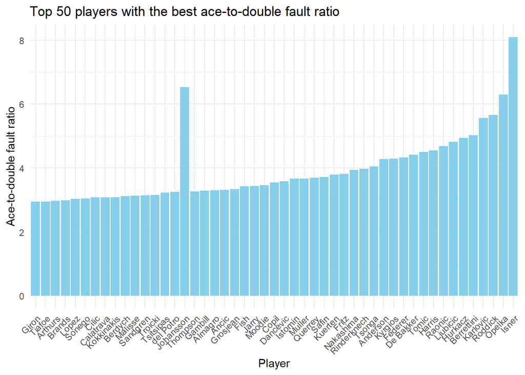

```r
players_filtrados = playersTotal[playersTotal$appearences >= 100, ]

players_ordenados = players_filtrados[order(players_filtrados$aces / players_filtrados$df,
                                             players_filtrados$player_id, decreasing = TRUE), ]

top_50_jugadores = head(players_ordenados, 50)

ggplot(top_50_jugadores, aes(x = reorder(name_last, aces / df), y = aces / df)) +
  geom_bar(stat = "identity", fill = "skyblue") +
  labs(
    title = "Top 50 players with the best ace-to-double fault ratio",
    x = "Player",
    y = "Ace-to-double fault ratio"
  ) +
  theme_minimal() +
  theme(axis.text.x = element_text(angle = 45, hjust = 1))
```

```r
top_50_jugadores
```

```
##       player_id  name_first   name_last hand      dob ioc height appearences
## 4544     104545        John       Isner    R 19850426 USA    206         770
## 24172    124187      Reilly      Opelka    R 19970828 USA    211         168
## 4053     104053        Andy     Roddick    R 19820830 USA    188         740
## 3333     103333         Ivo    Karlovic    R 19790228 CRO    208         679
## 26595    126610      Matteo  Berrettini    R 19960412 ITA    196         234
## 28019    128034      Hubert     Hurkacz    R 19970211 POL    196         278
## 3344     103344        Ivan    Ljubicic    R 19790319 CRO    193         585
## 5670     105683       Milos      Raonic    R 19901227 CAN    196         532
## 44735    144750       Lloyd      Harris    R 19970224 RSA    193         137
## 6057     106071     Bernard       Tomic    R 19921021 AUS    193         347
## 5210     105217      Thiemo   De Bakker    R 19880919 NED    193         133
## 3819     103819       Roger     Federer    R 19810808 SUI    185        1378
## 6387     106401        Nick     Kyrgios    R 19950427 AUS    193         298
## 4728     104731       Kevin    Anderson    R 19860518 RSA    203         600
```

[output cut: 138 more lines]

Once the previous chart is obtained, we create a scatter plot that represents the proportion of double faults relative to the total number of aces. With this, we can visualize the 50 best servers on the ATP tour.

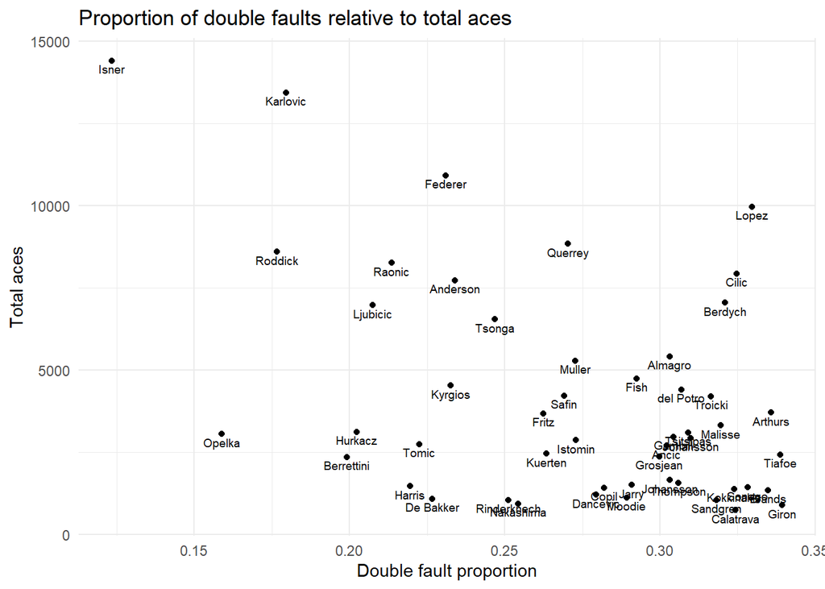

```r
library(ggplot2)

ggplot(top_50_jugadores, aes(x = df / aces, y = aces, label = name_last)) +
  geom_point() +
  geom_text(aes(x = df / aces, y = aces), nudge_x = 0, nudge_y = -100, size = 2.5, vjust = 1) +
  labs(
    title = "Proportion of double faults relative to total aces",
    x = "Double fault proportion",
    y = "Total aces"
  ) +
  theme_minimal()
```

#### 4.1. **Wins by country**

Bar chart representing the 30 countries with the most wins

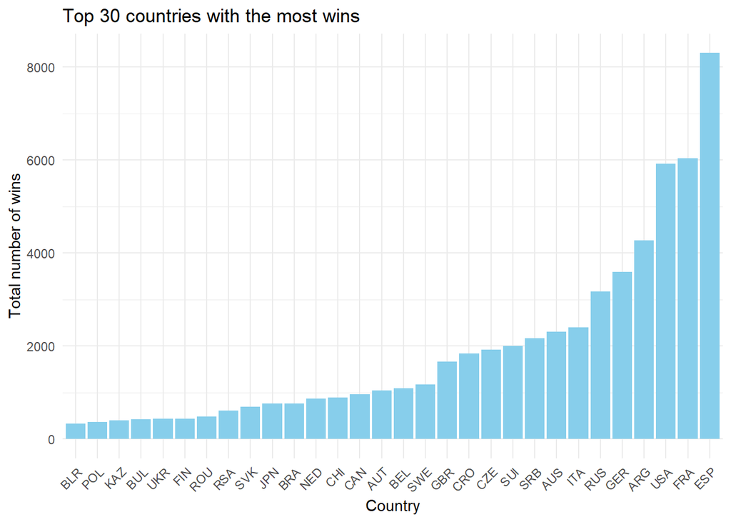

```r
victorias_por_pais = aggregate(wins ~ ioc, data = playersTotal, sum)

victorias_por_pais = victorias_por_pais[order(victorias_por_pais$wins, decreasing = TRUE), ]

top_30_paises = head(victorias_por_pais, 30)

ggplot(top_30_paises, aes(x = reorder(ioc, wins), y = wins)) +
  geom_bar(stat = "identity", fill = "skyblue") +
  labs(
    title = "Top 30 countries with the most wins",
    x = "Country",
    y = "Total number of wins"
  ) +
  theme_minimal() +
  theme(axis.text.x = element_text(angle = 45, hjust = 1))
```

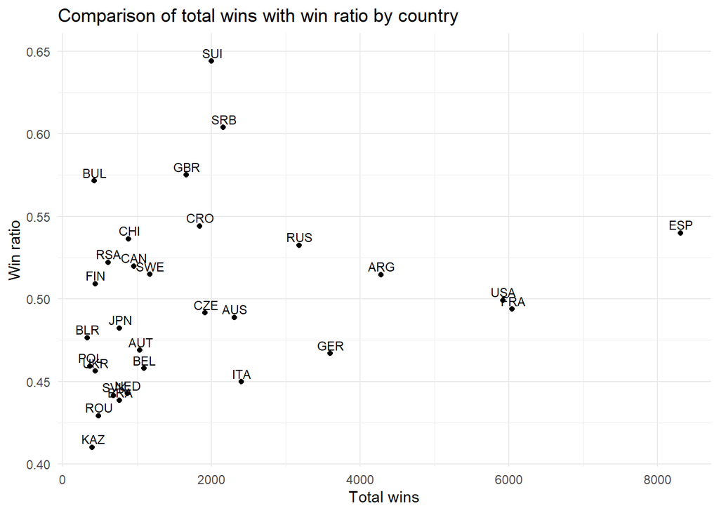

```r
partidos_por_pais = aggregate(appearences ~ ioc, data = playersTotal, sum)

victorias_por_pais = aggregate(wins ~ ioc, data = playersTotal, sum)

datos_paises = merge(partidos_por_pais, victorias_por_pais, by = "ioc")

datos_paises$proporcion_victorias = datos_paises$wins / datos_paises$appearences

datos_paises = datos_paises[order(datos_paises$wins, decreasing = TRUE), ]

top_30_paises = head(datos_paises, 30)

ggplot(top_30_paises, aes(x = wins, y = proporcion_victorias, label = ioc)) +
  geom_point() +
  geom_text(nudge_x = 10, nudge_y = 0.005, size = 3) +  # Adjust the position of the labels
  labs(
    title = "Comparison of total wins with win ratio by country",
    x = "Total wins",
    y = "Win ratio"
  ) +
  theme_minimal()
```